# quick-introduction

Version Note: Up-to-date with v0.3.0

```r
library(psycModel)
```

# Why should you use this pacakge?

TLDR:  
1) It is a beginner-friendly R package for statistical analysis in social science.  
2) Tired of manually writing all variables in a model? You can use [dplyr::select()](https://dplyr.tidyverse.org/reference/select.html) syntax for all models  
3) Fitting models, plotting, checking goodness of fit, and model assumption violations all in one place.  
4) Beautiful and easy-to-read output. Check out this [example](https://jasonmoy28.github.io/psycModel/articles/quick-introduction.html) now.

Support models:  
1. Linear regression (i.e., support ANOVA, ANCOVA), generalized linear regression.  
2. Linear mixed effect model (or HLM to be more specific), generalized linear mixed effect model.  
3. Confirmatory and exploratory factor analysis.  
4. Simple mediation analysis.  
5. Reliability analysis.  
6. Correlation, descriptive statistics (e.g., mean, SD).

At its core, this package allows people to analyze their data with one simple function call. For example, when you are running a linear regression, you need to fit the model, check the goodness of fit (e.g., R2), check the model assumption, and plot the interaction (if the interaction is included). Without this package, you need several packages to do the above steps. Additionally, if you are an R beginner, you probably don’t know where to find all these R packages. This package has done all that work for you, so you can just do everything with one simple function call.

Another good example is CFA. The most common (and probably the only) option to fit a CFA in R is using lavaan. Lavaan has its own unique set of syntax. It is very versatile and powerful, but you do need to spend some time learning it. It may not worth the time for people who just want to run a quick and simple CFA model. In my package, it’s very intuitive with `cfa_summary(data, x1:x3)`, and you get the model summary, the fit measures, and a nice-looking path diagram. The same logic also applies to HLM since `lme4` / `nlme` also has its own set of syntax that you need to learn.

Moreover, I also made fitting the model even simpler by using the `dplyr::select` syntax. In short, traditionally, if you want to fit a linear regression model, the syntax looks like this `lm(y ~ x1 + x2 + x3 + x4 + ... + xn, data)`. Now, the syntax is much shorter and more intuitive: `lm_model(y, x1:xn, data)`. You can even replace `x1:xn` with `everything()`. I also wrote this very short [article](https://jasonmoy28.github.io/psycModel/articles/brief-introduction-to-select-syntax.html) that teaches people how to use the `dplyr::select()` syntax (it is not comprehensive, and it is not intended to be).

Finally, I made the output in R much more beautiful and easy to read. The default output from R, to be frank, look ugly. I spent a lot of time making sure it looks good in this package (see below for examples). I am sure that you will see how big the improvement is.

# Regression Models

## Integrated Summary for Linear Regression

`integrated_model_summary` is the integrated function for linear regression and generalized linear regression. It will first fit the model using `lm_model` or `glm_model`, then it will pass the fitted model object to `model_summary` which produces model estimates and assumption checks. If interaction terms are included, they will be passed to the relevant interaction_plot function for plotting (the package currently does not support generalized linear regression interaction plotting).

Additionally, you can request `assumption_plot` and `simple_slope` (default is `FALSE`). By requesting `assumption_plot`, it produces a panel of graphs that allow you to visually inspect the model assumption (in addition to testing it statistically). `simple_slope` is another powerful way to probe further into the interaction. It shows you the slope estimate at the mean and +1/-1 SD of the mean of the moderator. For example, you hypothesized that social-economic status (SES) moderates the effect of teacher experience on education quality. Then, simple_slope shows you the slope estimate of teacher experience on education quality at +1/-1 SD and the mean level of SES. Additionally, it produces a Johnson-Newman plot that shows you at what level of the moderator that the slope_estimate is predicted to be insignificant.

```
Model Summary
Model Type = Linear regression
Outcome = Sepal.Length
Predictors = Sepal.Width, Petal.Length, Petal.Width, Species

Model Estimates
───────────────────────────────────────────────────────────────────────────────────────
                Parameter  Coefficient     SE       t   df          p            95% CI
───────────────────────────────────────────────────────────────────────────────────────
              (Intercept)        1.652  0.434   3.807  143  0.000 ***  [ 0.794,  2.510]
              Sepal.Width        0.645  0.128   5.023  143  0.000 ***  [ 0.391,  0.899]
             Petal.Length        0.837  0.068  12.240  143  0.000 ***  [ 0.702,  0.972]
              Petal.Width        0.220  0.375   0.588  143  0.558      [-0.520,  0.961]
        Speciesversicolor       -0.770  0.241  -3.196  143  0.002 **   [-1.246, -0.294]
         Speciesvirginica       -1.110  0.337  -3.296  143  0.001 ***  [-1.775, -0.444]
  Sepal.Width:Petal.Width       -0.159  0.102  -1.560  143  0.121      [-0.360,  0.042]
───────────────────────────────────────────────────────────────────────────────────────

Goodness of Fit
───────────────────────────────────────────────────
     AIC      BIC     R²  R²_adjusted   RMSE      σ
───────────────────────────────────────────────────
  78.584  102.669  0.870        0.864  0.298  0.305
───────────────────────────────────────────────────

Model Assumption Check
OK: Residuals appear to be independent and not autocorrelated (p = 0.870).
OK: residuals appear as normally distributed (p = 0.813).
OK: No outliers detected.
- Based on the following method and threshold: cook (0.91).
- For variable: (Whole model)

OK: Error variance appears to be homoscedastic (p = 0.109).
Multicollinearity is not checked for models with interaction terms. You may check multicollinearity among predictors of a model without interaction terms
```

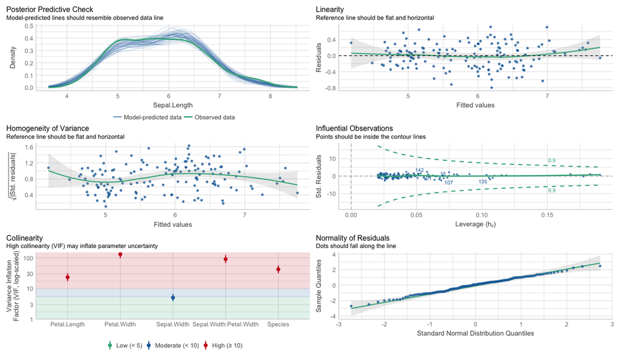

```
Slope Estimates at Each Level of Moderators
────────────────────────────────────────────────────────────────────
  Petal.Width Level   Est.   S.E.  t val.          p          95% CI
────────────────────────────────────────────────────────────────────
                Low  0.576  0.100   5.770  0.000 ***  [0.379, 0.773]
               Mean  0.455  0.090   5.075  0.000 ***  [0.278, 0.632]
               High  0.334  0.135   2.476  0.014 *    [0.067, 0.600]
────────────────────────────────────────────────────────────────────
Note: For continuous variable, low and high represent -1 and +1 SD from the mean, respectively.
```

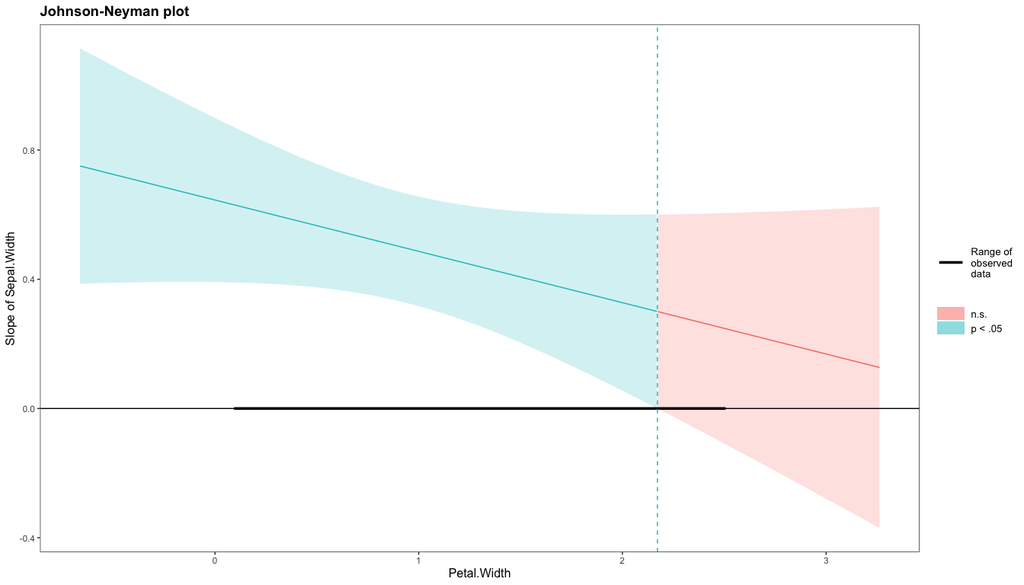

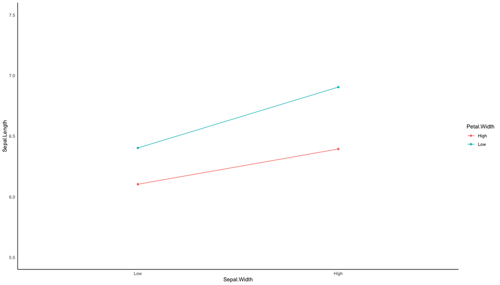

```r
lm_model_summary(
   data = iris,
   response_variable = Sepal.Length,
   predictor_variable = tidyselect::everything(),
   two_way_interaction_factor = c(Sepal.Width, Petal.Width),
   model_summary = TRUE,
   interaction_plot = TRUE,
   assumption_plot = TRUE,
   simple_slope = TRUE,
   plot_color = TRUE
 )
```

## Integrated summary for Multilevel Model

This is the multilevel-variation of `integrated_model_summary`. It works exactly the same way as `integrated_model_summary` except you need to specify the non_random_effect_factors (i.e., level-2 factors) and the random_effect_factors (i.e., the level-1 factors) instead of `predictor_variable`.

```
Model Summary
Model Type = Linear Mixed Effect Model (fitted using lme4 or lmerTest)
Outcome = popular
Predictors = extrav, sex, texp, extrav:sex, extrav:texp, sex:texp, extrav:sex:texp

Model Estimates
─────────────────────────────────────────────────────────────────────────────────────────────
        Parameter  Std_Coefficient     SE       t    df  Effects          p            95% CI
─────────────────────────────────────────────────────────────────────────────────────────────
      (Intercept)            0.000  0.000  -2.839  1988    fixed  0.005 **   [ 0.000,  0.000]
           extrav            0.688  0.048  14.345  1988    fixed  0.000 ***  [ 0.594,  0.781]
              sex            0.236  0.137   1.726  1988    fixed  0.085      [-0.032,  0.505]
             texp            1.020  0.100  10.198  1988    fixed  0.000 ***  [ 0.823,  1.216]
       extrav:sex            0.211  0.131   1.610  1988    fixed  0.108      [-0.046,  0.468]
      extrav:texp           -0.563  0.087  -6.451  1988    fixed  0.000 ***  [-0.734, -0.392]
         sex:texp            0.154  0.151   1.017  1988    fixed  0.309      [-0.143,  0.450]
  extrav:sex:texp           -0.133  0.138  -0.961  1988    fixed  0.337      [-0.404,  0.138]
─────────────────────────────────────────────────────────────────────────────────────────────

Goodness of Fit
────────────────────────────────────────────────────────────────────────────────
       AIC      AICc       BIC  R²_conditional  R²_marginal    ICC   RMSE      σ
────────────────────────────────────────────────────────────────────────────────
  4823.684  4823.841  4890.894           0.709        0.554  0.349  0.721  0.743
────────────────────────────────────────────────────────────────────────────────

Model Assumption Check
OK: Model is converged
OK: No singularity is detected
Warning: Autocorrelated residuals detected (p < .001).
OK: residuals appear as normally distributed (p = 0.425).
OK: No outliers detected.
- Based on the following method and threshold: cook (0.92).
- For variable: (Whole model)

OK: Error variance appears to be homoscedastic (p = 0.758).
Multicollinearity is not checked for models with interaction terms. You may check multicollinearity among predictors of a model without interaction terms
```

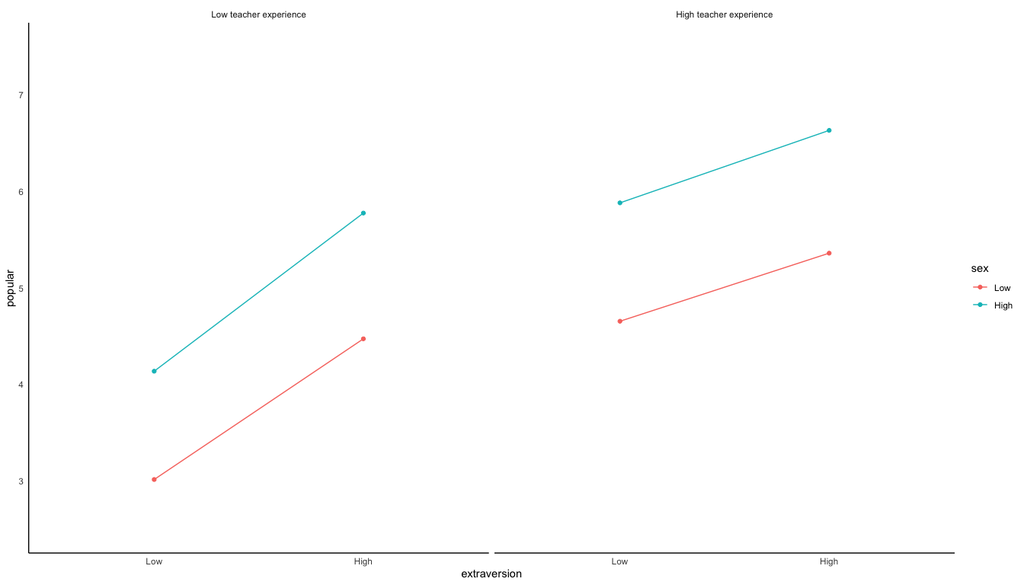

```r
lme_multilevel_model_summary(
    data = popular,
    response_variable = popular,
    random_effect_factors = extrav,
    non_random_effect_factors = c(sex, texp),
    three_way_interaction_factor = c(extrav, sex, texp),
   graph_label_name = c("popular", "extraversion", "sex", "teacher experience"), # change interaction plot label
   id = class,
   model_summary = TRUE,
   interaction_plot = TRUE,
   assumption_plot = FALSE, # you can try set to TRUE
   simple_slope = FALSE, # you can try set to TRUE
   plot_color = TRUE
 )
```

## Model comparison

This can be used to compared model. All type of model comparison supported by `performance::compare_performance()` are supported since this is just a wrapper for that function.

```r
 fit1 <- lm_model(
   data = popular,
   response_variable = popular,
   predictor_var = c(sex, extrav),
   quite = TRUE
 )

 fit2 <- lm_model(
   data = popular,
   response_variable = popular,
   predictor_var = c(sex, extrav),
   two_way_interaction_factor = c(sex, extrav),
   quite = TRUE
 )

 compare_fit(fit1, fit2)
```

```
Model Summary
Model Type = Model Comparison

─────────────────────────────────────────────────────────────────────────────
  Model       AIC  AIC_wt       BIC  BIC_wt     R2  R2_adjusted   RMSE  Sigma
─────────────────────────────────────────────────────────────────────────────
     lm  5977.415   0.727  5999.819   0.978  0.394        0.393  1.076  1.077
     lm  5979.369   0.273  6007.374   0.022  0.394        0.393  1.076  1.077
─────────────────────────────────────────────────────────────────────────────
```

# Structure Equation Modeling

## Confirmatory Factor Analysis

CFA model is fitted using `lavaan::cfa()`. You can pass multiple factor (in the below example, x1, x2, x3 represent one factor, x4,x5,x6 represent another factor etc.). It will show you the fit measure, factor loading, and goodness of fit based on cut-off criteria (you should review literature for the cut-off criteria as the recommendations are subjected to changes). Additionally, it will show you a nice-looking path diagram.

```r
cfa_summary(
   data = lavaan::HolzingerSwineford1939,
   x1:x3,
   x4:x6,
   x7:x9
 )
```

```
Model Summary
Model Type = Confirmatory Factor Analysis
Model Formula =
. DV1 =~ x1 + x2 + x3
  DV2 =~ x4 + x5 + x6
  DV3 =~ x7 + x8 + x9

Fit Measure
─────────────────────────────────────────────────────────────────────────────────────
      Χ²      DF          P    CFI  RMSEA   SRMR    TLI       AIC       BIC      BIC2
─────────────────────────────────────────────────────────────────────────────────────
  85.306  24.000  0.000 ***  0.931  0.092  0.065  0.896  7517.490  7595.339  7528.739
─────────────────────────────────────────────────────────────────────────────────────


Factor Loadings
────────────────────────────────────────────────────────────────────────────────
  Latent.Factor  Observed.Var  Std.Est     SE       Z          P          95% CI
────────────────────────────────────────────────────────────────────────────────
            DV1            x1    0.772  0.055  14.041  0.000 ***  [0.664, 0.880]
                           x2    0.424  0.060   7.105  0.000 ***  [0.307, 0.540]
                           x3    0.581  0.055  10.539  0.000 ***  [0.473, 0.689]
            DV2            x4    0.852  0.023  37.776  0.000 ***  [0.807, 0.896]
                           x5    0.855  0.022  38.273  0.000 ***  [0.811, 0.899]
                           x6    0.838  0.023  35.881  0.000 ***  [0.792, 0.884]
            DV3            x7    0.570  0.053  10.714  0.000 ***  [0.465, 0.674]
                           x8    0.723  0.051  14.309  0.000 ***  [0.624, 0.822]
                           x9    0.665  0.051  13.015  0.000 ***  [0.565, 0.765]
────────────────────────────────────────────────────────────────────────────────


Model Covariances
──────────────────────────────────────────────────────────────
  Var.1  Var.2    Est     SE      Z          P          95% CI
──────────────────────────────────────────────────────────────
    DV1    DV2  0.459  0.064  7.189  0.000 ***  [0.334, 0.584]
    DV1    DV3  0.471  0.073  6.461  0.000 ***  [0.328, 0.613]
    DV2    DV3  0.283  0.069  4.117  0.000 ***  [0.148, 0.418]
──────────────────────────────────────────────────────────────

```

[output cut: 12 more lines]

```
   x8  0.477  0.073   6.531  0.000 ***  [0.334, 0.620]
   x9  0.558  0.068   8.208  0.000 ***  [0.425, 0.691]
  DV1  1.000  0.000     NaN    NaN      [1.000, 1.000]
  DV2  1.000  0.000     NaN    NaN      [1.000, 1.000]
  DV3  1.000  0.000     NaN    NaN      [1.000, 1.000]
──────────────────────────────────────────────────────


Goodness of Fit:
 Warning. Poor χ² fit (p < 0.05). It is common to get p < 0.05. Check other fit measure.
 OK. Acceptable CFI fit (CFI > 0.90)
 Warning. Poor RMSEA fit (RMSEA > 0.08)
 OK. Good SRMR fit (SRMR < 0.08)
 Warning. Poor TLI fit (TLI < 0.90)
 OK. Barely acceptable factor loadings (0.4 < some loadings < 0.7)
```

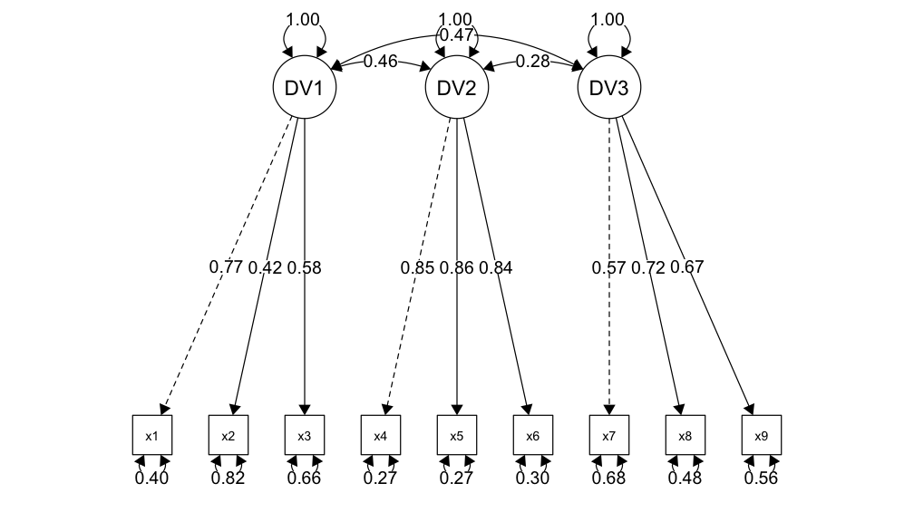

## Exploratory Factor Analysis

EFA model is fitted using `psych::fa()`. It first find the optimal number of factor. Then, it will show you the factor loading, uniqueness, complexity of the latent factor (loading < 0.4 are hided for better viewing experience). You can additionally request running a post-hoc CFA model based on the EFA model.

```r
efa_summary(lavaan::HolzingerSwineford1939,
            starts_with("x"), # x1, x2, x3 ... x9
            post_hoc_cfa = TRUE) # run a post-hoc CFA
```

```
Model Summary
Model Type = Exploratory Factor Analysis
Optimal Factors = 3

Factor Loadings
────────────────────────────────────────────────────────────────
  Variable  Factor 1  Factor 3  Factor 2  Complexity  Uniqueness
────────────────────────────────────────────────────────────────
        x1               0.613                 1.539       0.523
        x2               0.494                 1.093       0.745
        x3               0.660                 1.084       0.547
        x4     0.832                           1.104       0.272
        x5     0.859                           1.043       0.246
        x6     0.799                           1.167       0.309
        x7                         0.709       1.062       0.481
        x8                         0.699       1.131       0.480
        x9               0.415     0.521       2.046       0.540
────────────────────────────────────────────────────────────────


Explained Variance
─────────────────────────────────────────────────────
                    Var  Factor 1  Factor 3  Factor 2
─────────────────────────────────────────────────────
            SS loadings     2.187     1.342     1.329
         Proportion Var     0.243     0.149     0.148
         Cumulative Var     0.243     0.392     0.540
   Proportion Explained     0.450     0.276     0.274
  Cumulative Proportion     0.450     0.726     1.000
─────────────────────────────────────────────────────


EFA Model Assumption Test:
OK. Bartlett's test of sphericity suggest the data is appropriate for factor analysis. χ²(36) = 904.097, p < 0.001
OK. KMO measure of sampling adequacy suggests the data is appropriate for factor analysis. KMO = 0.752

KMO Measure of Sampling Adequacy
────────────────────
      Var  KMO Value
────────────────────
  Overall      0.752
       x1      0.805
       x2      0.778
       x3      0.734
       x4      0.763
       x5      0.739
       x6      0.808
       x7      0.593
       x8      0.683
       x9      0.788
────────────────────
```

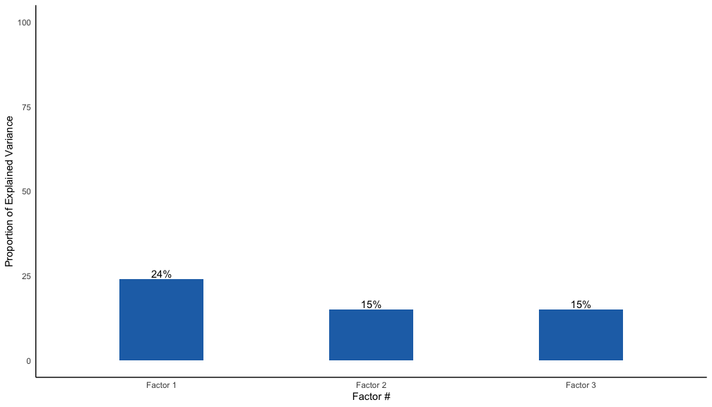

```
Post-hoc CFA Model Summary

Fit Measure
─────────────────────────────────────────────────────────────────────────────────────
      Χ²      DF          P    CFI  RMSEA   SRMR    TLI       AIC       BIC      BIC2
─────────────────────────────────────────────────────────────────────────────────────
  85.306  24.000  0.000 ***  0.931  0.092  0.065  0.896  7517.490  7595.339  7528.739
─────────────────────────────────────────────────────────────────────────────────────


Factor Loadings
────────────────────────────────────────────────────────────────────────────────
  Latent.Factor  Observed.Var  Std.Est     SE       Z          P          95% CI
────────────────────────────────────────────────────────────────────────────────
       Factor.1            x4    0.852  0.023  37.776  0.000 ***  [0.807, 0.896]
                           x5    0.855  0.022  38.273  0.000 ***  [0.811, 0.899]
                           x6    0.838  0.023  35.881  0.000 ***  [0.792, 0.884]
       Factor.3            x1    0.772  0.055  14.041  0.000 ***  [0.664, 0.880]
                           x2    0.424  0.060   7.105  0.000 ***  [0.307, 0.540]
                           x3    0.581  0.055  10.539  0.000 ***  [0.473, 0.689]
       Factor.2            x7    0.570  0.053  10.714  0.000 ***  [0.465, 0.674]
                           x8    0.723  0.051  14.309  0.000 ***  [0.624, 0.822]
                           x9    0.665  0.051  13.015  0.000 ***  [0.565, 0.765]
────────────────────────────────────────────────────────────────────────────────


Goodness of Fit:
 Warning. Poor χ² fit (p < 0.05). It is common to get p < 0.05. Check other fit measure.
 OK. Acceptable CFI fit (CFI > 0.90)
 Warning. Poor RMSEA fit (RMSEA > 0.08)
 OK. Good SRMR fit (SRMR < 0.08)
 Warning. Poor TLI fit (TLI < 0.90)
 OK. Barely acceptable factor loadings (0.4 < some loadings < 0.7)
```

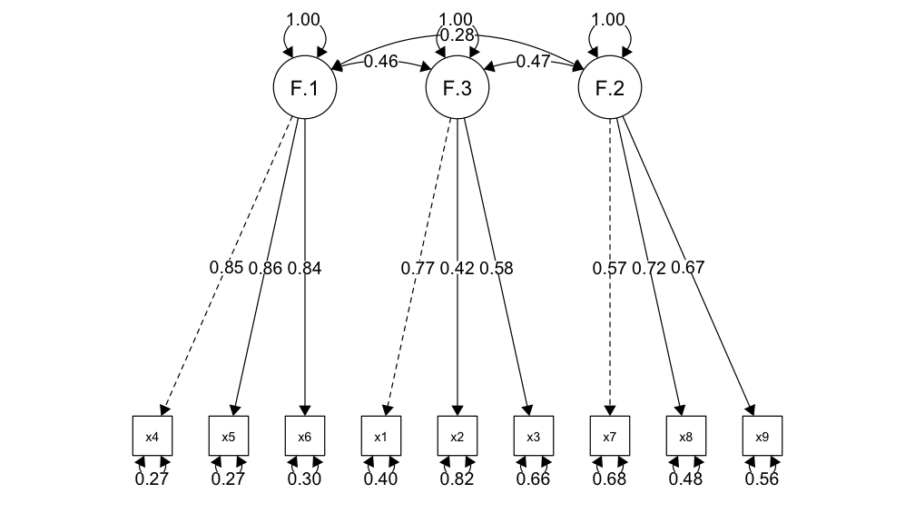

## Measurement Invariance

Measurement invariance is fitted using `lavaan::cfa()`. It uses the multi-group confirmatory factor analysis approach. You can request metric or scalar invariance by specifying the `invariance_level` (mainly to save time. If you have a large model, it doesn’t make sense to fit a unnecessary scalar invariance model if you are only interested in metric invariance)

```r
 measurement_invariance(
   x1:x3,
   x4:x6,
   x7:x9,
   data = lavaan::HolzingerSwineford1939,
   group = "school",
   invariance_level = "scalar" # you can change this to metric
 )
```

```
Computing CFA using:
  DV1 =~ x1 + x2 + x3
  DV2 =~ x4 + x5 + x6
  DV3 =~ x7 + x8 + x9
 [1] "Computing for configural model"
[1] "Computing for metric model"
[1] "Computing for scalar model"

Model Summary
Model Type = Measurement Invariance
Comparsion Type = Configural-Metric-Scalar Comparsion
Group = school
Model Formula =
. DV1 =~ x1 + x2 + x3
  DV2 =~ x4 + x5 + x6
  DV3 =~ x7 + x8 + x9


Fit Measure Summary
──────────────────────────────────────────────────────────────────────────────────────────────────────────
    Analysis Type       Χ²      DF          P     CFI   RMSEA   SRMR     TLI       AIC       BIC      BIC2
──────────────────────────────────────────────────────────────────────────────────────────────────────────
       configural  115.851  48.000  0.000 ***   0.923   0.097  0.068   0.885  7484.395  7706.822  7516.536
           metric  124.044  54.000  0.000 ***   0.921   0.093  0.072   0.895  7480.587  7680.771  7509.514
           scalar  164.103  60.000  0.000 ***   0.882   0.107  0.082   0.859  7508.647  7686.588  7534.359
                .
  metric - config    8.192   6.000  0.000 ***  -0.002  -0.004  0.004   0.009    -3.808   -26.050    -7.022
  scalar - metric   40.059   6.000  0.000 ***  -0.038   0.015  0.011  -0.036    28.059     5.817    24.845
──────────────────────────────────────────────────────────────────────────────────────────────────────────

Goodness of Fit:
 OK. Excellent measurement metric-invariance based on |ΔCFI| < 0.005
 OK. Excellent measurement metric-invariance based on |ΔRMSEA| < 0.01
 OK. Good measurement metric-invariance based on ΔSRMR < 0.03
 Warning. Unacceptable measurement scalar-invariance based on |ΔCFI| > 0.01
 Warning. Unacceptable measurement scalar-invariance based on |ΔRMSEA| > 0.015.
OK. Good measurement scalar-invariance based on ΔSRMR < 0.015
```

## Mediation Model

Currently, the package only support simple mediation with covariate. You can try to fit a multi-group mediation by specifying the group argument. But, honestly, I don’t know that’s the correct approach to implement it. If you want more complicated mediation, I highly recommend using the `mediation` package. Eventually, I probably will switch to using that for this package.

```r
mediation_summary(
  data = lmerTest::carrots,
  response_variable = Preference,
  mediator = Sweetness,
  predictor_variable = Crisp,
  control_variable = Age:Income
)
```

```
Model Summary
Model Type = Mediation Analysis (fitted using lavaan)

Effect Summary
────────────────────────────────────────────────────────────────
  Effect Type  Est.Std     SE       z          p          95% CI
────────────────────────────────────────────────────────────────
       direct    0.238  0.028   8.400  0.000 ***  [0.182, 0.293]
     indirect    0.222  0.017  12.987  0.000 ***  [0.188, 0.255]
        total    0.459  0.022  20.583  0.000 ***  [0.416, 0.503]
────────────────────────────────────────────────────────────────

Regression Summary
──────────────────────────────────────────────────────────────────────────────────────
    Response  Operator    Predict  Est.Std     SE       z          p            95% CI
──────────────────────────────────────────────────────────────────────────────────────
   Sweetness         ~      Crisp    0.550  0.019  29.119  0.000 ***  [ 0.513,  0.587]
  Preference         ~  Sweetness    0.403  0.027  14.862  0.000 ***  [ 0.350,  0.456]
  Preference         ~      Crisp    0.238  0.028   8.400  0.000 ***  [ 0.182,  0.293]
  Preference         ~        Age    0.130  0.027   4.776  0.000 ***  [ 0.077,  0.184]
  Preference         ~   Homesize   -0.133  0.026  -5.061  0.000 ***  [-0.184, -0.081]
  Preference         ~       Work   -0.048  0.027  -1.756  0.079      [-0.101,  0.006]
  Preference         ~     Income    0.015  0.026   0.577  0.564      [-0.035,  0.065]
──────────────────────────────────────────────────────────────────────────────────────
```

# Other Model

## Reliability Analysis

It will first determine whether your item is uni- or multidimensionality. If it is unidimensional, then it will compute the alpha and the single-factor CFA model. If it is multidimensional, then it will compute the alpha and the omega. It also provide descriptive statistics. Here is an example for unidimensional items:

```r
reliability_summary(data = lavaan::HolzingerSwineford1939, cols = x1:x3)
```

```
Model Summary
Model Type = Reliability Analysis
Dimensionality = uni-dimensionality

Composite Reliability Measures
────────────────────────────
  Alpha  Alpha.Std  G6 (smc)
────────────────────────────
  0.626      0.627     0.535
────────────────────────────

Item Reliability (item dropped)
─────────────────────────────────
  Var  Alpha  Alpha.Std  G6 (smc)
─────────────────────────────────
   x1  0.507      0.507     0.340
   x2  0.612      0.612     0.441
   x3  0.458      0.458     0.297
─────────────────────────────────

CFA Model:
Factor Loadings
───────────────────────────────────────────────────────────────────────────────
  Latent.Factor  Observed.Var  Std.Est     SE      Z          P          95% CI
───────────────────────────────────────────────────────────────────────────────
            DV1            x1    0.621  0.067  9.223  0.000 ***  [0.489, 0.753]
                           x2    0.479  0.063  7.645  0.000 ***  [0.356, 0.602]
                           x3    0.710  0.071  9.936  0.000 ***  [0.570, 0.850]
───────────────────────────────────────────────────────────────────────────────

Descriptive Statistics Table:

─────────────────────────────────────────
  Var   mean     sd         x1         x2
─────────────────────────────────────────
   x1  4.936  1.167
   x2  6.088  1.177  0.297 ***
   x3  2.250  1.131  0.441 ***  0.340 ***
─────────────────────────────────────────
```

Here is an example for multidimensional items:

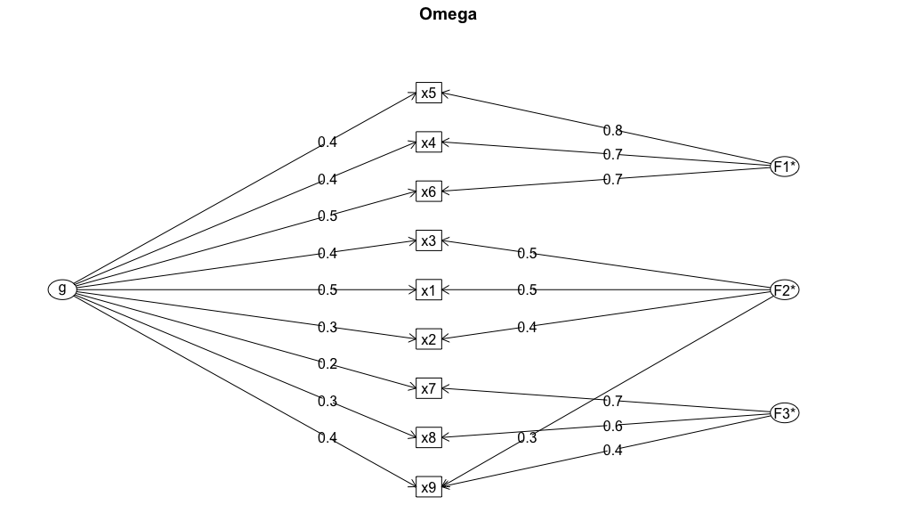

```
Model Summary
Model Type = Reliability Analysis
Dimensionality = multi-dimensionality

Composite Reliability Measures
──────────────────────────────────────────────────────────
  Alpha  Alpha.Std    G.6  Omega.Hierarchical  Omega.Total
──────────────────────────────────────────────────────────
   0.76       0.76  0.808               0.449        0.851
──────────────────────────────────────────────────────────

Item Reliability (item dropped)
─────────────────────────────────
  Var  Alpha  Alpha.Std  G6 (smc)
─────────────────────────────────
   x1  0.725      0.725     0.780
   x2  0.764      0.763     0.811
   x3  0.749      0.748     0.796
   x4  0.715      0.719     0.761
   x5  0.724      0.726     0.764
   x6  0.714      0.717     0.764
   x7  0.766      0.765     0.800
   x8  0.748      0.747     0.789
   x9  0.731      0.728     0.782
─────────────────────────────────

Descriptive Statistics Table:

───────────────────────────────────────────────────────────────────────────────────────────────────────────────────
  Var   mean     sd          x1          x2          x3          x4          x5          x6          x7          x8
───────────────────────────────────────────────────────────────────────────────────────────────────────────────────
   x1  4.936  1.167
   x2  6.088  1.177   0.297 ***
   x3  2.250  1.131   0.441 ***   0.340 ***
   x4  3.061  1.164   0.373 ***   0.153       0.159
   x5  4.341  1.290   0.293 ***   0.139       0.077       0.733 ***
   x6  2.186  1.096   0.357 ***   0.193   *   0.198  **   0.704 ***   0.720 ***
   x7  4.186  1.090   0.067      -0.076       0.072       0.174   *   0.102       0.121
   x8  5.527  1.013   0.224  **   0.092       0.186   *   0.107       0.139       0.150       0.487 ***
   x9  5.374  1.009   0.390 ***   0.206  **   0.329 ***   0.208  **   0.227  **   0.214  **   0.341 ***   0.449 ***
───────────────────────────────────────────────────────────────────────────────────────────────────────────────────
```

```r
reliability_summary(data = lavaan::HolzingerSwineford1939, cols = x1:x9)
```

## Correlation

There isn’t much to say about correlation except that you can request different type of correlation based on the data structure. In the backend, I use the `correlation` package for this.

```r
cor_test(iris, where(is.numeric))
```

```
Model Summary
Model Type = Correlation
Model Method = pearson
Adjustment Method = holm

───────────────────────────────────────────────────────
           Var  Sepal.Length  Sepal.Width  Petal.Length
───────────────────────────────────────────────────────
  Sepal.Length
   Sepal.Width    -0.118
  Petal.Length     0.872 ***   -0.428 ***
   Petal.Width     0.818 ***   -0.366 ***     0.963 ***
───────────────────────────────────────────────────────
```

## Descriptive Table

It put together a nice table of some descriptive statistics and the correlation. Nothing fancy.

```r
descriptive_table(iris, cols = where(is.numeric)) # all numeric columns
```

```
Model Summary
Model Type = Descriptive Statistics

─────────────────────────────────────────────────────────────────────
           Var   mean     sd  Sepal.Length  Sepal.Width  Petal.Length
─────────────────────────────────────────────────────────────────────
  Sepal.Length  5.843  0.828
   Sepal.Width  3.057  0.436    -0.118
  Petal.Length  3.758  1.765     0.872 ***   -0.428 ***
   Petal.Width  1.199  0.762     0.818 ***   -0.366 ***     0.963 ***
─────────────────────────────────────────────────────────────────────
```

## Knit to R Markdown

if you want to produce these beautiful output in R Markdown. Calls this function and see the most up-to-date advice.

```r
knit_to_Rmd()
```

```
OK. Required package "fansi" is installed

Note: To knit Rmd to HTML, add the following line to the setup chunk of your Rmd file:
 "old.hooks <- fansi::set_knit_hooks(knitr::knit_hooks)"

Note: Use html_to_pdf to convert it to PDF. See ?html_to_pdf for more info
```

# Ending

This conclude my briefed discussion of this package. There are some more additionally functions (like `cfa_groupwise`) that probably have fewer use cases. You can check out what they do by enter `?cfa_groupwise`. Anyway, that’s it. I hope you enjoy the package, and please let me know if you have any feedback. If you like it, please considering giving a star on [GitHub](https://github.com/jasonmoy28/psycModel). Thank you.